# Campo Abierto - Tracking

Heatmaps y Rasters de Trayectorias

Autor/a

Afiliación

Garcia Rios Santiago

[Facultad de Ciencias](https://www.fciencias.unam.mx/)

Fecha de publicación

28 de septiembre de 2024

**Tip**

Para descargar las carpetas de github de maner fácil, se puede usar la siguiente página: [https://download-directory.github.io/(https://download-directory.github.io/)]

Cargar librerías necesarias. Esta función instala las librerías necesarias si no están instaladas.

```r
# escribir librerías necesarias
list.of.packages <- c("Rtrack", "paletteer", "viridis", "viridisLite")
# funcion para cargar e instalar librerías faltantes
new.packages <- list.of.packages[!(list.of.packages %in% installed.packages()[,"Package"])]
if(length(new.packages)) install.packages(new.packages)

# cargar librerías
library(Rtrack) # para leer experimentos y graficar
library(paletteer) # paletas de colores
library(viridis) # paletas de colores
library(viridisLite) # paletas de colores
```

Ahora, tenemos que leer las trayectorias de los animales y graficarlas.

1. **Leer experimento**

Se necesitan dos cosas. Primero, un archivo de Excel (`.xlsx`) que contenga los siguientes campos:

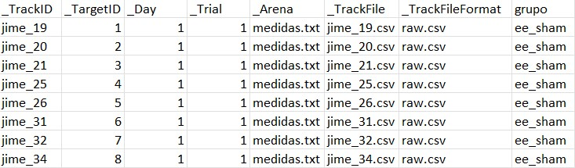

imagen

`_TrackID` es el nombre del archivo de las coordenadas de cada animal.  
`_TargetID` es el nombre arbitrario que permita identificar a cada animal.  
`_Day` es el día del experimento; dejar en 1 si no se tienen datos de varios días. `_Trial` dejar en 1. `_Arena` dejar como está para cada exprimento. `_TrackFile` nombre del archivo de las coordenadas CON la extensión .csv. El archivo excel lo hace automaticamente solo arrastrando ya que tiene la fórmula `=A2&".csv"`. `_TrackFileFormat` dejar como está. `grupo` opcional, para identificar a los animales en grupos.

Ahora, necesitamos las coordenadas exportadas de un software de tracking en una carpeta en formato `csv`. **NOTA** Dependiente de la versión de anymaze.. este tiende a poner los nombres de las columnas en formatos no consistentes. Lo mejor es abrir el archivo en excel y cambiar el nombre de las columnas a `Time`, `X` y `Y` para evitar problemas. Guardar como CSV. T debe ser segundos.

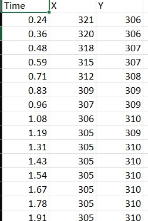

Figura 1

Las coordenadas en X y y deben estar en Pixeles, de la siguiente manera:

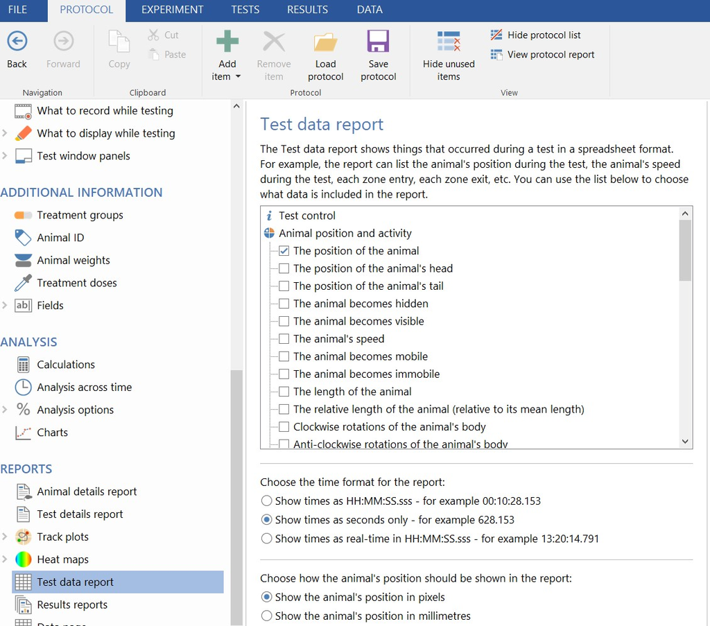

Y se exportan a la carpeta así:

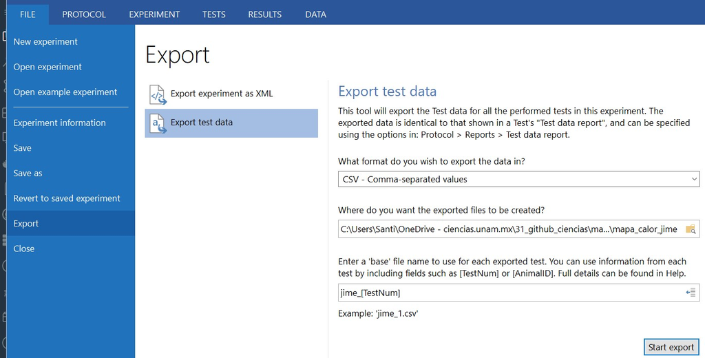

Al final, las coordenadas deben de quedar como en la Figura 1.

**Nota**

**Cómo organizar las carpetas**

El script principal (puedes copiar y pegar este archivo o descargarlo desde github) debe estar en la carpeta principal. Dentro de esta carpeta, se deben de tener una carpeta: `experimentos`. En la carpeta `experimentos`, crear subcarpetas para cada experimento que se quiera hacer el mapa de calor. Además, en la carpeta `experimentos` debe estar el archivo de texto con los parámetros del experimento (copiar y pegar de github) y el excel con los datos de los animales. Debe quedar así:

[figure not shown]

Script principal llamado index.qmd

[figure not shown]

Organización de la Subcarpetas experimentos.

Esto es lo más dificil, ahora solo necesitamos correr el código y ajustar los colores:

Leer el experimento deseado, donde `experimento.ee.rad.postcums` es el nombre del experimento del archivo excel y data.dir las coordenadas exportadas de dicho experimento.

```r
experimento.ee.rad.postcums = Rtrack::read_experiment("./experimentos/ee_sham_post.xlsx", data.dir = "./experimentos/ee_sham_post")
```

```
    Processing tracks.
```

Ahora lo podemos graficar. Para los colores, podemos hacer dos cosas.

En este código, se usa una paleta predefinida de colores del paquete viridis. Ajustar con estos nombres en el código para obtener el resultado deseado:

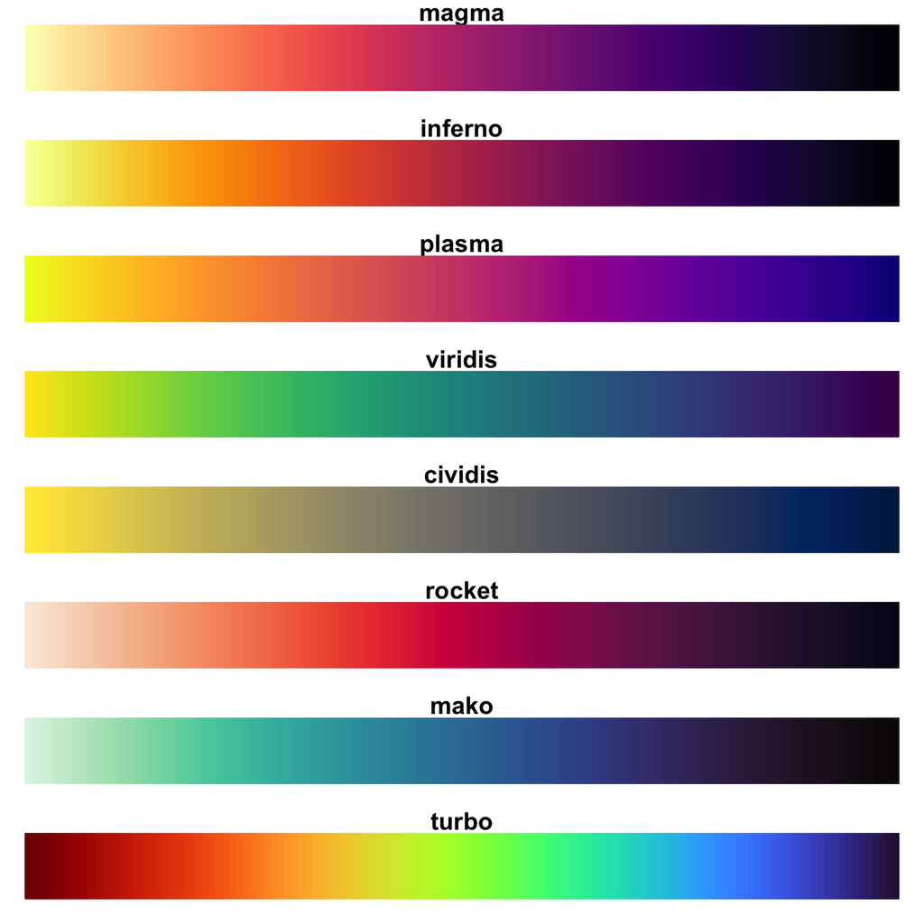

Ejemplos de la paleta de colores viridis

Cambiar el argumento `col = viridis(300)` por la paleta que se quiera. El número es la cantidad de colores en la paleta, entre más colores, más detallado el mapa de calor.

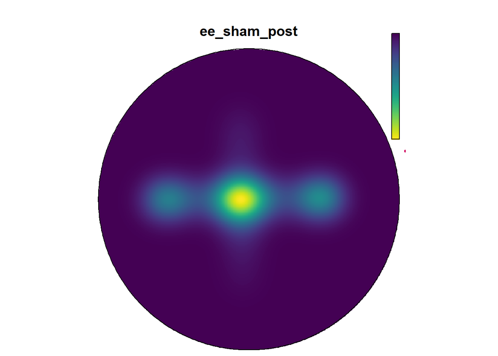

```r
Rtrack::plot_density(
  experimento.ee.rad.postcums$metrics,
  title = "ee_sham_post",
  col = viridis(300),
  resolution = 900,
  feature.col = "#D20062",
  feature.lwd = 4,
  legend = TRUE
)
```

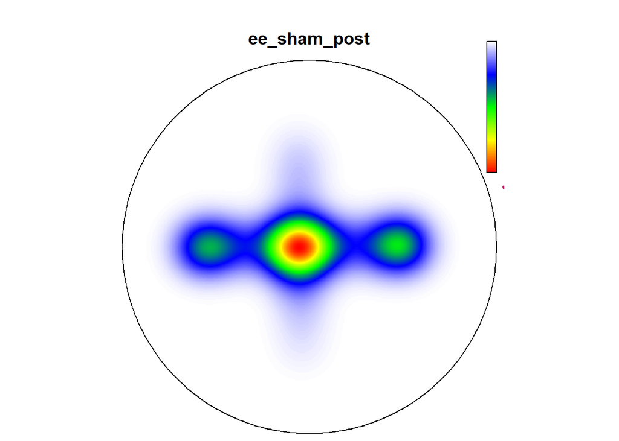

```r
Rtrack::plot_density(
  experimento.ee.rad.postcums$metrics,
  title = "ee_sham_post",
  colorRampPalette(c("white", "blue", "green", "yellow", "red"))(400),
  resolution = 900,
  feature.col = "#D20062",
  feature.lwd = 4,
  legend = TRUE
)
```

**Tip**

Se pueden usar los colores que se quieran. En este caso, se usan los colores de la paleta `colorRampPalette(c("white", "blue", "green", "yellow", "red"))(400)`. Cambiar los colores por los deseados, donde white es el color que corresponde a la menor densidad y red a la mayor densidad. Para ajustar mejor, usar los colores `hex`. Para esto, visitar esta página: [https://htmlcolorcodes.com/es/](https://htmlcolo%20rcodes.com/es/) y copiar el código `hex` del color deseado de esta manera: `colorRampPalette(c("#FFFFFF", "#0000FF", "#00FF00", "#FFFF00", "#FF0000"))(400)`.

Por úlitmo, se puede guardar la imagen y borrar en photoshop o photopea los elementos que no se quieran, y agregar las paredes del laberinto. Repetir para todos los experimentos deseados.